# Week_1_Homework

Christophe

August 29, 2015

Chapter 1: 1.8, 1.10, 1.28, 1.36, 1.48, 1.50, 1.56, 1.70

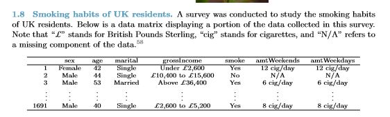

1. What does each row of the data matrix represent?

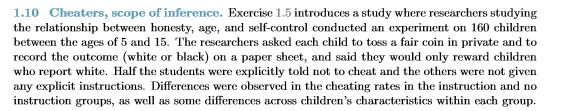

1. Identify the population of interest and the sample in this study.

> The population of interest is children and the sample is 160 children between the ages of 5 and 15.
2. Comment on whether or not the results of the study can be generalized to the population, and if the findings of the study can be used to establish causal relationships.

> The results of the study can generalized to the population because the sample appears to be representative of the true population. However, there could be some unanticipated bias introduced in the sampling process.

> Additional tests would be important to confirm the statistical significance of the findings and correlation does not always equal causation. However, because they conducted a randomized experiement they could infer caustion in this study.

1.28 Reading the paper. Below are excerpts from two articles published in the NY Times:

1. An article titled Risks: Smokers Found More Prone to Dementia states the following:

###### “Researchers analyzed data from 23,123 health plan members who participated in a voluntary exam and health behavior survey from 1978 to 1985, when they were 50-60 years old. 23 years later, about 25% of the group had dementia, including 1,136 with Alzheimer’s disease and 416 with vascular dementia. After adjusting for other factors, the researchers concluded that pack-aday smokers were 37% more likely than nonsmokers to develop dementia, and the risks went up with increased smoking; 44% for one to two packs a day; and twice the risk for more than two packs.”

Based on this study, can we conclude that smoking causes dementia later in life? Explain your reasoning.

> We cannot conclude that there is caustion and that smoking causes dementia. We can only infer that smoking and dementia appear highly correlated and are associated with each other. The reason we are limited in our inferance is that this is simply a health survey and no experiement has taken place to control for other confounding factors. Also, this observational study can not be replicated to confirm results but it does point to a specific area for further studies.
2. Another article titled The School Bully Is Sleepy states the following:

###### “The University of Michigan study, collected survey data from parents on each child’s sleep habits and asked both parents and teachers to assess behavioral concerns. About a third of the students studied were identified by parents or teachers as having problems with disruptive behavior or bullying. The researchers found that children who had behavioral issues and those who were identified as bullies were twice as likely to have shown symptoms of sleep disorders.” A friend of yours who read the article says, “The study shows that sleep disorders lead to bullying in school children.”

Is this statement justified? If not, how best can you describe the conclusion that can be drawn from this study?

> The statement is not justified because this is simply an observational study. The conclusion that can be drawn from this article is that sleep disorder and bullying are highly associated but neither can be labeled as causing the other. The friend could just as easily conclude that bullying causes sleep disorders because there is no controlling for confounding issues. The article mentions behavioral issues, which could have a greater impact on the sleep disorder and bullying. Again, the issue is that an experiment would need to take place to determine the cause and effect of these variables and if there were some other factor at play in causing this high association or does one truly cause the other.

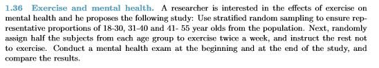

1. What type of study is this?

> This is a randomized experiment
2. What are the treatment and control groups in this study?

> The treatment group is the the group excersising twice a week and the control group is the group that does not exercise
3. Does this study make use of blocking? If so, what is the blocking variable?

> It does make use of blocking through the age strata, the blocking variable is age.
4. Does this study make use of blinding?

> No it doesn’t, the patient will know they are in the group that does not exercise as they would be instructed to do as such
5. Comment on whether or not the results of the study can be used to establish a causal relationship between exercise and mental health, and indicate whether or not the conclusions can be generalized to the population at large.

> Only using the information provided the study could be used to establish a causal relationship between exercise and mental health because the use of control groups will allow for testing of only the vairable exercise on the outcome of interest which is mental health. The conclusions could not be used for the population at large because people that are aged below 18 or above 55 are not represented in this study.
6. Suppose you are given the task of determining if this proposed study should get funding. Would you have any reservations about the study proposal?

> I would assume that proposal of this type would have more details but assuming that I do not have more information I would not fund this study as is. The set up appears strong but the outcome of interest is vague as “mental health” can mean a number of things and there is no clear measure. Also, instructing people to not exercise crosses into a moral dilemma and I would have strong reservations about possible enforcing some bad behaviors and even helping a person establish a bad habit of not exercising. I think this could be changed if the participants did not exercise already but then the sample would be skewed to those who do not excerise.

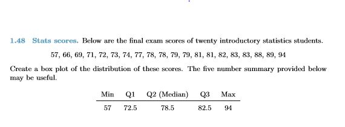

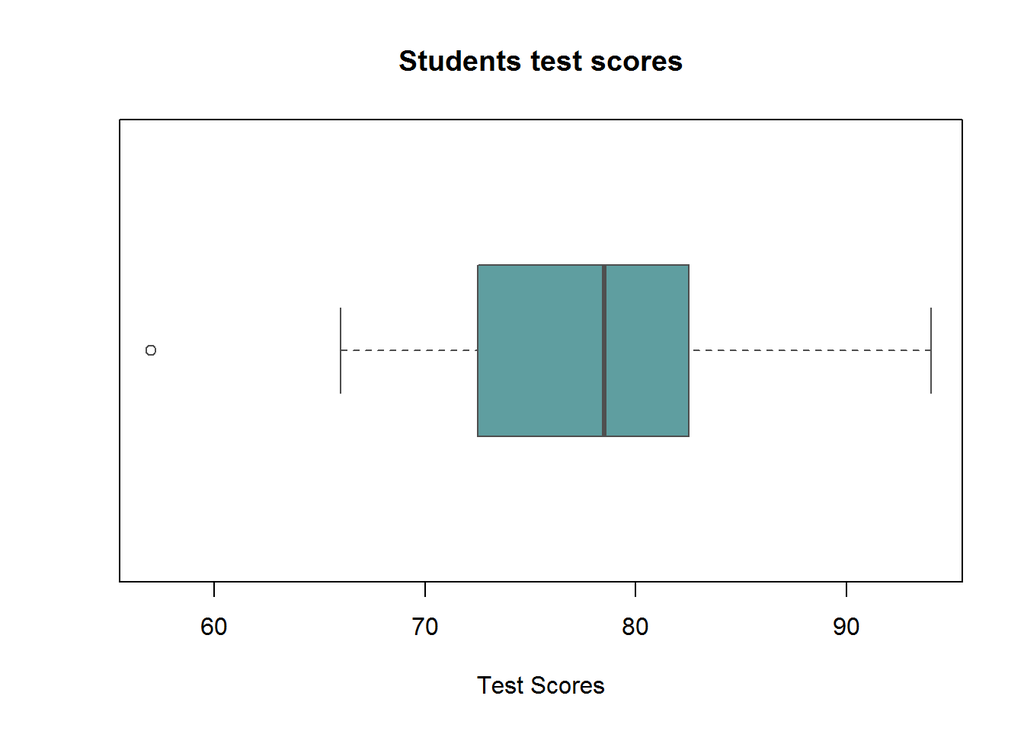

[figure not shown]

```r
scores <- c(57, 66, 69, 71, 72, 73, 74, 77, 78, 78, 79, 79, 81, 81, 82, 83, 83, 88, 89, 94)
boxplot(scores, col = "cadetblue", horizontal = TRUE, border = "gray31", xlab = "Test Scores", main = "Students test scores")
```

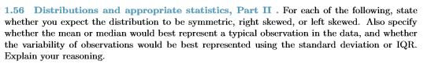

1. Housing prices in a country where 25% of the houses cost below $350,000, 50% of the houses cost below $450,000, 75% of the houses cost below $1,000,000 and there are a meaningful number of houses that cost more than $6,000,000.

> I would expect the distribution to be right skewed. The median would best respresent house prices in this country because the over 6 million dollar houses would skew a mean. The variation would be best explained by IQR, as the over 6 million dollar houses would skew the standard deviation greatly.
2. Housing prices in a country where 25% of the houses cost below $300,000, 50% of the houses cost below $600,000, 75% of the houses cost below $900,000 and very few houses that cost more than $1,200,000.

> I would expected the distribution to be symetrical and normally distributed. While the mean could potentially provided an acceptable measure of a typical value, it can be changed greatly by any outliers. Therefore, the median remains the best measure of central tendency. The variability of the observation could easily be represented by standard deviation because the distribution appears to be very normal.
3. Number of alcoholic drinks consumed by college students in a given week. Assume that most of these students don’t drink since they are under 21 years old, and only a few drink excessively.

> I would assume that this would be right skewed distribution in that a majority of students will drink none or very little. While the mean could potentially provided an acceptable measure of a typical value, it can be changed greatly by any outliers. Therefore, the median remains the best measure of central tendency. The variation would be best explained by IQR, as those that drink excessively may skew a standard deviation greatly.
4. Annual salaries of the employees at a Fortune 500 company where only a few high level executives earn much higher salaries than the all other employees

> I would assume that this would be a normal distribution of salaries with a vew outliers. Due to the employees that have much greater salaries than the majority of other employees it would be best to use the median as the mean has a breakdown point of 0 so it would be skewed greatly by the outliers. The variation would be best explained by IQR, as those that make significantly more than other employees would be skewing the results.

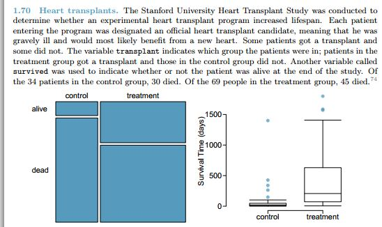

1. Based on the mosaic plot, is survival independent of whether or not the patient got a transplant? Explain your reasoning.

> Survival is not independent of treatment, if it were I would expect relatively similar numbers for control and treatment group. However, we do see a difference in outcomes based on the mosiac plot.
2. What do the box plots below suggest about the efficacy (effectiveness) of the heart transplant treatment.

> The boxplot shows a very promising outcome of higher life expectancy for those recieving the treatment than those that did not recieve the treatment. Its fairly intuitive that we would expect gravely ill patients receiving a new heart to at least have a longer life expectancy than those that continue to be gravely ill with no intervention.
3. What proportion of patients in the treatment group and what proportion of patients in the control group died?

We write alive on `28` cards representing patients who were alive at the end of the study, and dead on `75` cards representing patients who were not. Then, we shuffle these cards and split them into two groups: one group of size `69` representing treatment, and another group of size `34` representing control. We calculate the difference between the proportion of dead cards in the treatment and control groups (treatment -control) and record this value. We repeat this 100 times to build a distribution centered at `approximately zero assuming the independence model is true`. Lastly, we calculate the fraction of simulations where the simulated differences in proportions are `equal to or greater than our observation in the study`. If this fraction is low, we conclude that it is unlikely to have observed such an outcome by chance and that the null hypothesis should be rejected in favor of the alternative.

3. What do the simulation results shown below suggest about the effectiveness of the transplant program?

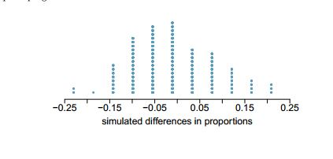

> The simulation results show that the effectiveness of the transplant program is that transplants has an effect on survival rates. The high rates of survival is actually due to the transplant and not due to random chance.